# Predicting Grain Crop Yields in India for Years 1997 - 2020

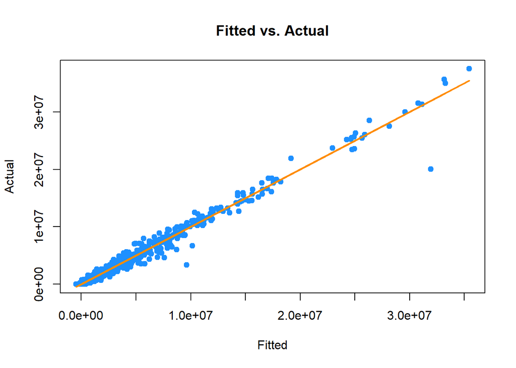

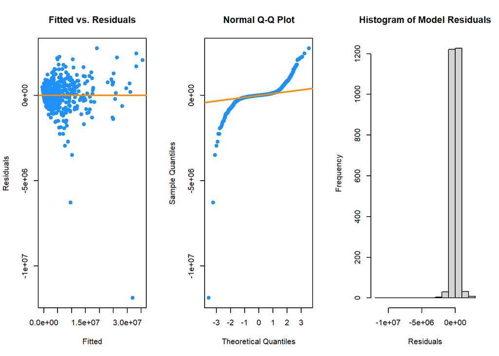

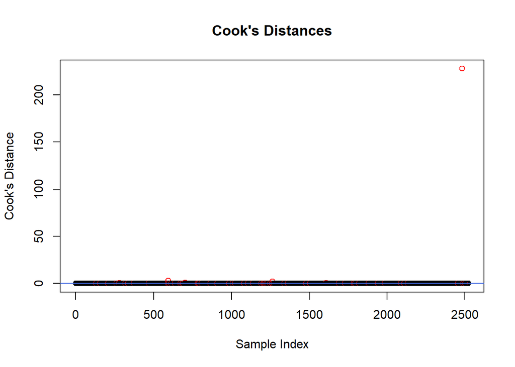

```
## [1] "LOOCV-RMSE:"      "2323344.92891856"
```

```r
multi.form.cropyear_omit <- as.formula(Production ~
  (poly(Area, degree = 2, raw = 1) +
    poly(Annual_Rainfall, degree = 2, raw = 1) +
    poly(Fertilizer, degree = 2, raw = 1) +
    poly(Pesticide, degree = 2, raw = 1) +
    I(sqrt(Area)) +
    I(sqrt(Annual_Rainfall)) +
    I(sqrt(Fertilizer)) +
    I(sqrt(Pesticide)) +
    I(log(Area)) +
    I(log(Annual_Rainfall)) +
    I(log(Fertilizer)) +
    I(log(Pesticide))) *
    (Crop + Season + Zone))
multi.full.cropyear_omit <- lm(multi.form.cropyear_omit, data = crops.train)
output_diagnostics(multi.full.cropyear_omit, vif = FALSE)
```

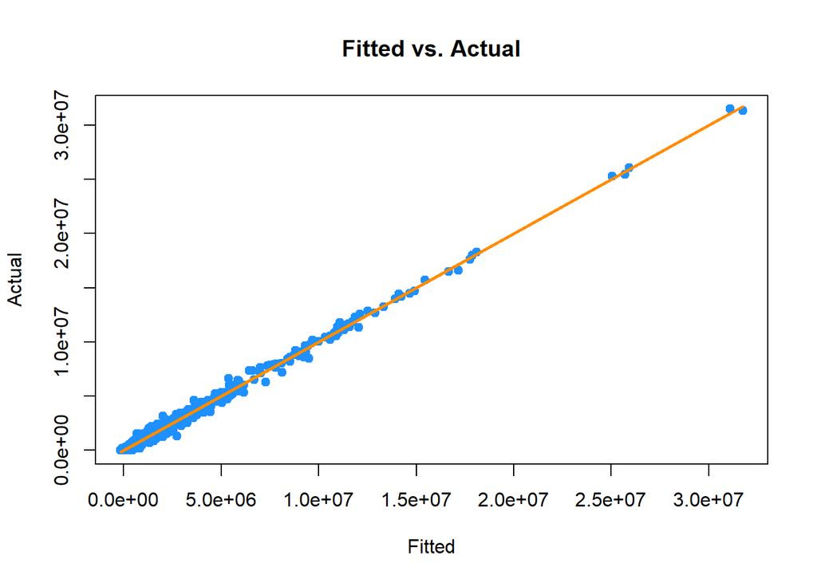

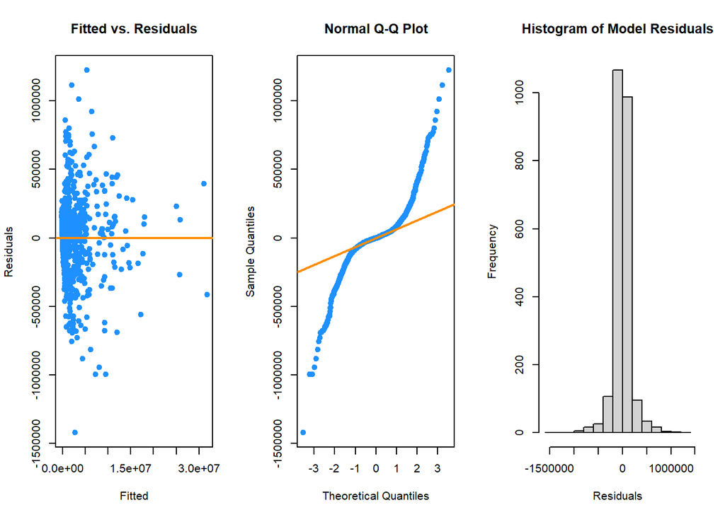

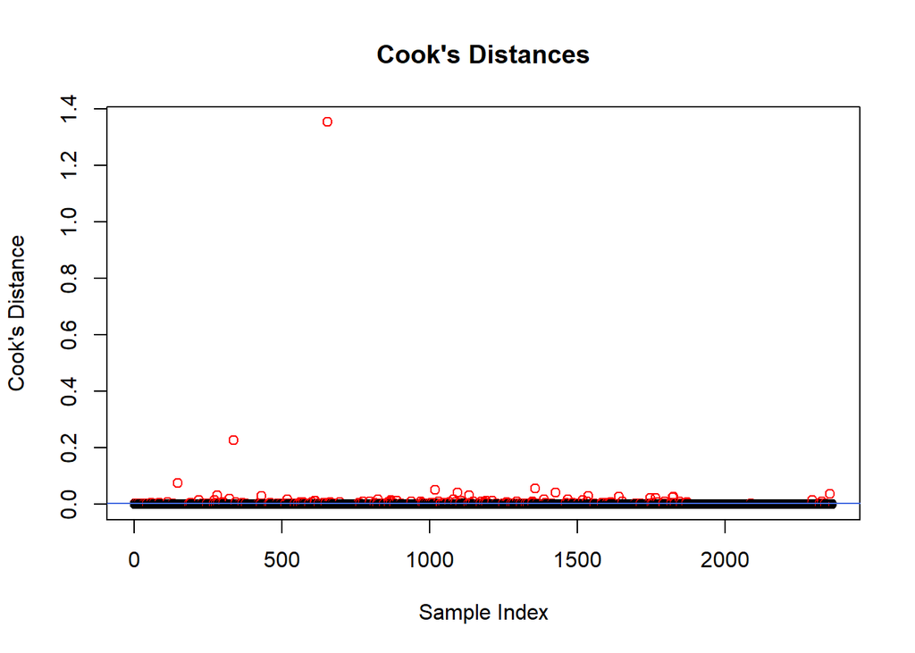

```
## [1] "LOOCV-RMSE:" "Inf"
```

```r
crops.train.multi.no_infl <- crops.train[!idx_infl_pts(multi.full.cropyear_omit), ]

multi.full.cropyear_omit <- lm(multi.form.cropyear_omit, data = crops.train.multi.no_infl)
output_diagnostics(multi.full.cropyear_omit, vif = FALSE)
```

```r
bc <- boxcox(multi.full.cropyear_omit)
```

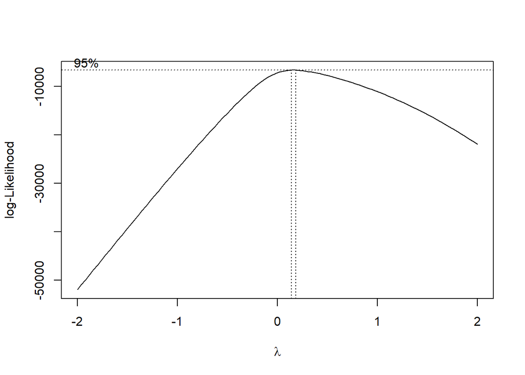

```r
(multi.full.bc.cropyear_omit_lambda <- bc$x[which.max(bc$y)])
```

```
## [1] 0.1414141
```

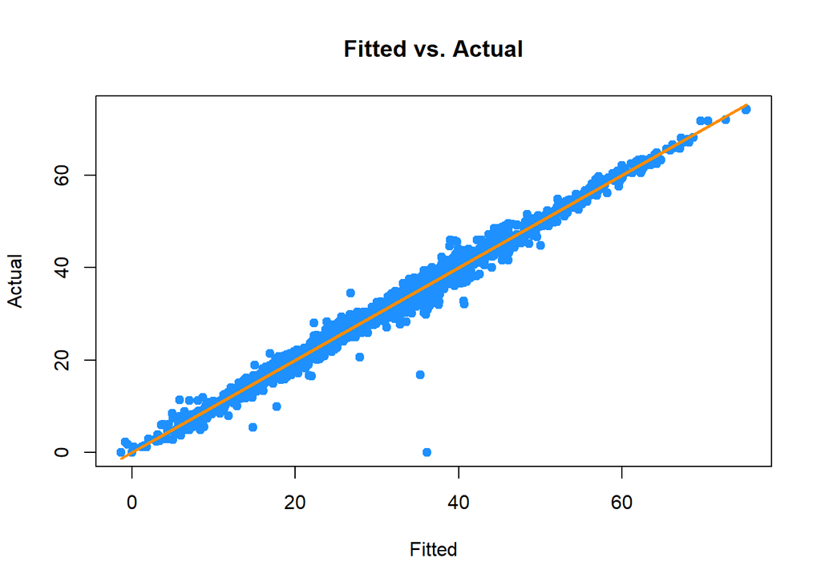

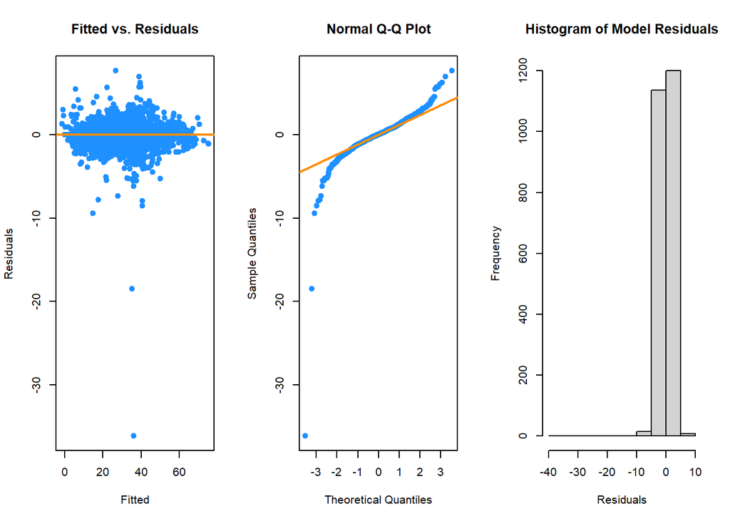

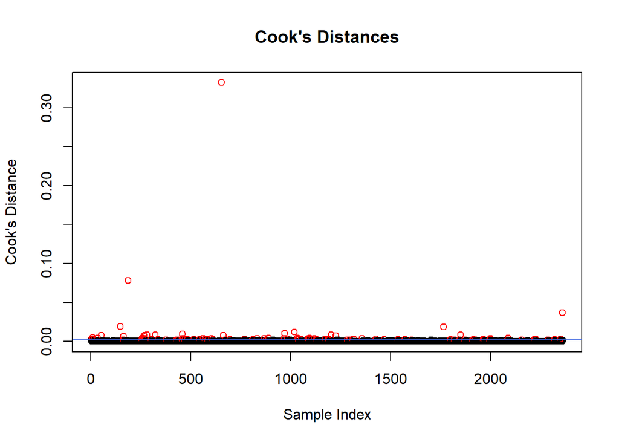

```
## [1] "LOOCV-RMSE:" "Inf"
```

```r
multi.full.bc.cropyear_omit <- lm(
  paste(
    "bc_transform(Production, multi.full.bc.cropyear_omit_lambda) ~ ",
    paste(
      attr(terms(multi.form.cropyear_omit),
        which = "term.labels"
      ),
      collapse = " + "
    )
  ),
  data = crops.train.multi.no_infl
)
output_diagnostics(multi.full.bc.cropyear_omit, vif = FALSE)
```

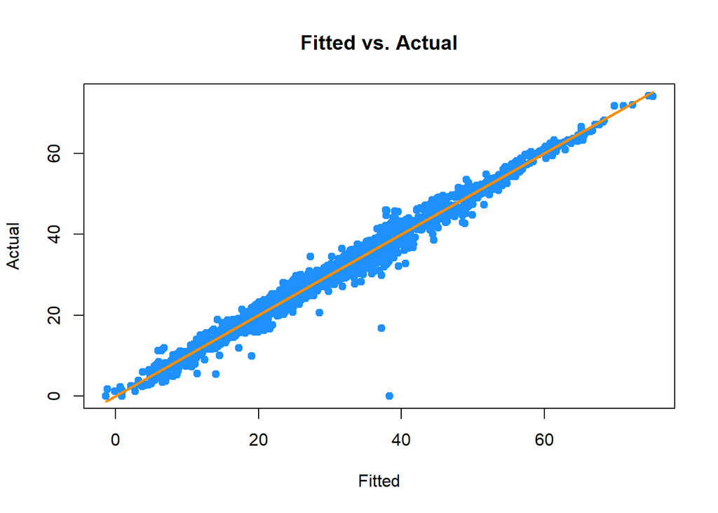

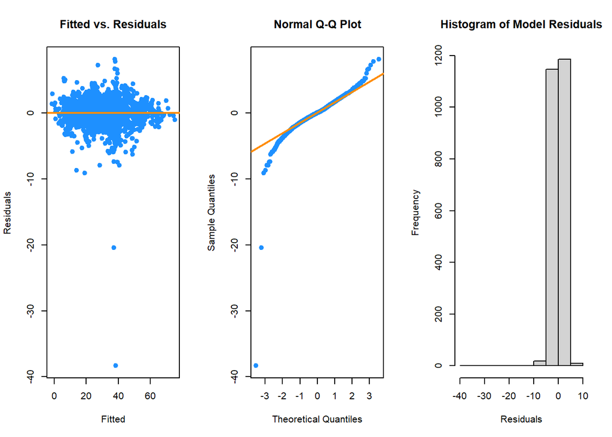

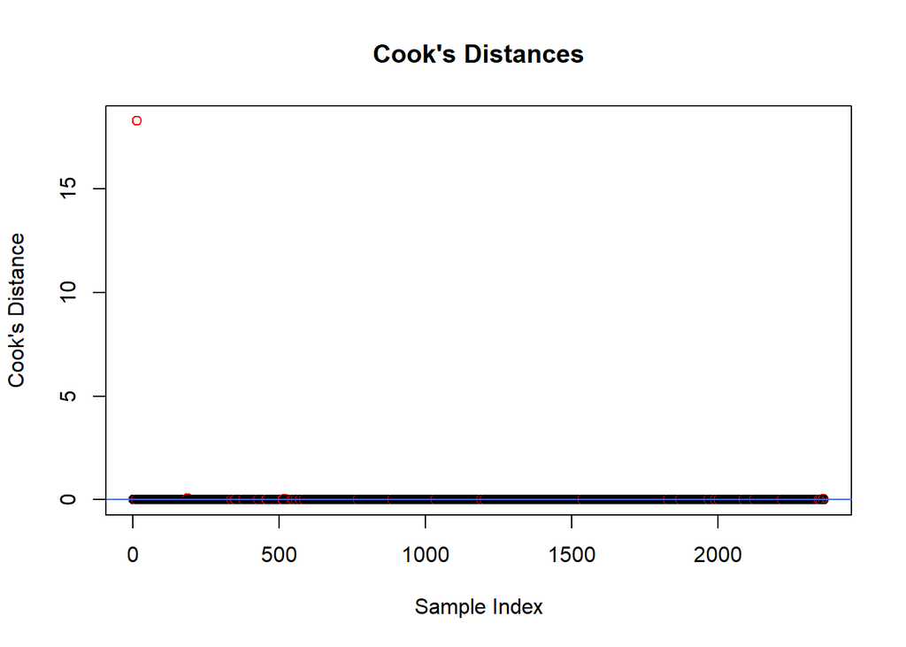

```
## [1] "LOOCV-RMSE:"      "2.50505305945477"
```

```r
multi.bic.forward.bc.cropyear_omit <- step(lm(bc_transform(Production, multi.full.bc.cropyear_omit_lambda) ~ 1, data = crops.train.multi.no_infl),
  scope = as.formula(
    paste(
      "bc_transform(Production, multi.full.bc.cropyear_omit_lambda) ~ ",
      paste(
        attr(terms(multi.form.cropyear_omit),
          which = "term.labels"
        ),
        collapse = " + "
      )
    )
  ),
  direction = "forward", trace = 0,
  k = log(nrow(crops.train.multi.no_infl))
)
output_diagnostics(multi.bic.forward.bc.cropyear_omit, vif = 0)
```

## Results

In the following section, we summarize results for the following models explored above:

```r
models.cropyear_cont <- list(
  baseline.poly.bc.cropyear_cont,
  multi.full.bc.cropyear_cont,
  multi.bic.forward.bc.cropyear_cont
)

models.cropyear_cat <- list(
  baseline.poly.bc.cropyear_cat,
  multi.full.bc.cropyear_cat,
  multi.bic.forward.bc.cropyear_cat
)

models.cropyear_omit <- list(
  baseline.poly.bc.cropyear_omit,
  multi.full.bc.cropyear_omit,
  multi.bic.forward.bc.cropyear_omit
)

models.cropyear_cont.lambdas <- rep(multi.full.bc.cropyear_cont_lambda, 3)
models.cropyear_cont.lambdas[1] <- baseline.poly.bc.cropyear_cont_lambda

models.cropyear_cat.lambdas <- rep(multi.full.bc.cropyear_cat_lambda, 3)
models.cropyear_cat.lambdas[1] <- baseline.poly.bc.cropyear_cat_lambda

models.cropyear_omit.lambdas <- rep(multi.full.bc.cropyear_omit_lambda, 3)
models.cropyear_omit.lambdas[1] <- baseline.poly.bc.cropyear_omit_lambda

modelNames.cropyear_cont <- list(
  "baseline.poly.bc.cropyear_cont",
  "multi.full.bc.cropyear_cont",
  "multi.bic.forward.bc.cropyear_cont"
)

modelNames.cropyear_cat <- list(
  "baseline.poly.bc.cropyear_cat",
  "multi.full.bc.cropyear_cat",
  "multi.bic.forward.bc.cropyear_cat"
)

modelNames.cropyear_omit <- list(
  "baseline.poly.bc.cropyear_omit",
  "multi.full.bc.cropyear_omit",
  "multi.bic.forward.bc.cropyear_omit"
)
```

```r
loocv_rmses.cropyear_cont <- rep(0, length(models.cropyear_cont))
train_rmses.cropyear_cont <- rep(0, length(models.cropyear_cont))
test_rmses.cropyear_cont <- rep(0, length(models.cropyear_cont))
train_adjr2.cropyear_cont <- rep(0, length(models.cropyear_cont))
num_predictors.cropyear_cont <- rep(0, length(models.cropyear_omit))
for (i in 1:length(models.cropyear_cont)) {
  num_predictors.cropyear_cont[i] <- length(coef(models.cropyear_cont[[i]]))
  loocv_rmses.cropyear_cont[i] <- get_loocv_rmse(models.cropyear_cont[[i]])
  train_rmses.cropyear_cont[i] <- sqrt(mean(resid(models.cropyear_cont[[i]])^2))

  lambda <- models.cropyear_cont.lambdas[i]

  if (lambda == -1) {
    actuals <- crops.test.cropyear_cont$Production
  } else {
    actuals <- bc_transform(crops.test.cropyear_cont$Production, lambda)
  }

  test_rmses.cropyear_cont[i] <- sqrt(
    mean(
      (actuals - predict(models.cropyear_cont[[i]], newdata = crops.test.cropyear_cont))^2
    )
  )
  train_adjr2.cropyear_cont[i] <- summary(models.cropyear_cont[[i]])$adj.r.squared
}

loocv_rmses.cropyear_cat <- rep(0, length(models.cropyear_cat))
train_rmses.cropyear_cat <- rep(0, length(models.cropyear_cat))
test_rmses.cropyear_cat <- rep(0, length(models.cropyear_cat))
train_adjr2.cropyear_cat <- rep(0, length(models.cropyear_cat))
num_predictors.cropyear_cat <- rep(0, length(models.cropyear_omit))
for (i in 1:length(models.cropyear_cat)) {
  num_predictors.cropyear_cat[i] <- length(coef(models.cropyear_cat[[i]]))
  loocv_rmses.cropyear_cat[i] <- get_loocv_rmse(models.cropyear_cat[[i]])
  train_rmses.cropyear_cat[i] <- sqrt(mean(resid(models.cropyear_cat[[i]])^2))

  lambda <- models.cropyear_cat.lambdas[i]

  if (lambda == -1) {
    actuals <- crops.test.cropyear_cat$Production
  } else {
    actuals <- bc_transform(crops.test.cropyear_cat$Production, lambda)
  }

  test_rmses.cropyear_cat[i] <- sqrt(
    mean(
      (actuals - predict(models.cropyear_cat[[i]], newdata = crops.test.cropyear_cat))^2
    )
  )
  train_adjr2.cropyear_cat[i] <- summary(models.cropyear_cat[[i]])$adj.r.squared
}
loocv_rmses.cropyear_omit <- rep(0, length(models.cropyear_omit))
train_rmses.cropyear_omit <- rep(0, length(models.cropyear_omit))
test_rmses.cropyear_omit <- rep(0, length(models.cropyear_omit))
train_adjr2.cropyear_omit <- rep(0, length(models.cropyear_omit))
num_predictors.cropyear_omit <- rep(0, length(models.cropyear_omit))
for (i in 1:length(models.cropyear_omit)) {
  num_predictors.cropyear_omit[i] <- length(coef(models.cropyear_omit[[i]]))
  loocv_rmses.cropyear_omit[i] <- get_loocv_rmse(models.cropyear_omit[[i]])
  train_rmses.cropyear_omit[i] <- sqrt(mean(resid(models.cropyear_omit[[i]])^2))

  lambda <- models.cropyear_omit.lambdas[i]

  if (lambda == -1) {
    actuals <- crops.test.cropyear_omit$Production
  } else {
    actuals <- bc_transform(crops.test.cropyear_omit$Production, lambda)
  }

  test_rmses.cropyear_omit[i] <- sqrt(
    mean(
      (actuals - predict(models.cropyear_omit[[i]], newdata = crops.test.cropyear_omit))^2
    )
  )
  train_adjr2.cropyear_omit[i] <- summary(models.cropyear_omit[[i]])$adj.r.squared
}

kable(data.frame(
  "Model" = do.call(c, c(modelNames.cropyear_cont, modelNames.cropyear_cat, modelNames.cropyear_omit)),
  "Num Predictors" = c(num_predictors.cropyear_cont, num_predictors.cropyear_cat, num_predictors.cropyear_omit),
  "LOOCV-RMSE" = c(loocv_rmses.cropyear_cont, loocv_rmses.cropyear_cat, loocv_rmses.cropyear_omit),
  "Train RMSE" = c(train_rmses.cropyear_cont, train_rmses.cropyear_cat, train_rmses.cropyear_omit),
  "Test RMSE" = c(test_rmses.cropyear_cont, test_rmses.cropyear_cat, test_rmses.cropyear_omit),
  "Train Adj R-Squared" = c(train_adjr2.cropyear_cont, train_adjr2.cropyear_cat, train_adjr2.cropyear_omit)
))
```

| Model | Num.Predictors | LOOCV.RMSE | Train.RMSE | Test.RMSE | Train.Adj.R.Squared |
| --- | --- | --- | --- | --- | --- |
| baseline.poly.bc.cropyear_cont | 165 | 1066.392438 | 51.793472 | 437.750473 | 0.9673315 |
| multi.full.bc.cropyear_cont | 315 | 348.953672 | 2.599787 | 4169.273533 | 0.9851238 |
| multi.bic.forward.bc.cropyear_cont | 84 | 8.271986 | 3.036487 | 3.267990 | 0.9814852 |
| baseline.poly.bc.cropyear_cat | 342 | 488.505295 | 48.007517 | 2849.934319 | 0.9646208 |
| multi.full.bc.cropyear_cat | 646 | Inf | 2.478714 | 29428.540824 | 0.9836288 |
| multi.bic.forward.bc.cropyear_cat | 71 | 3.072613 | 2.973799 | 3.610029 | 0.9804248 |
| baseline.poly.bc.cropyear_omit | 135 | 110.329830 | 52.361844 | 2891.019188 | 0.9657785 |
| multi.full.bc.cropyear_omit | 255 | Inf | 1.683657 | 32303.678633 | 0.9834977 |
| multi.bic.forward.bc.cropyear_omit | 71 | 2.505053 | 1.969801 | 186.379325 | 0.9792062 |

## Discussion

Not only do these models achieve good test performance, but they also strike a reasonable compromise in terms of satisfying our LINE assumptions. Our first, full additive model was very poor in terms of satisfying the equal variance and normality assumptions. By including several types of variable transformations on the predictors (polynomial, log, and square root), we saw significant improvement in terms of satisfying equal variance (as seen in the corresponding Fitted vs. Residual plots). Going further by including a box cox transformation of the response we saw significantly improved performance against the normality assumptions.

On the topic of our crop year experiments, it turns out that whether the crop year variable is categorical or continuous did not differentiate the models on its own, but it is very important for predictive power. When omitted the model(s) performed significantly worse.